# Reaction times for Estonian case-inflected nouns: solution

```r
library(mgcViz);
load(paste0(goodLocation, "/data/est.rda"))

m1 <- qgamV(RT ~ InfFamSize + Age + LogFrequency + WordLength + Trial,
            data=est, qu=0.5)
```

```
## Estimating learning rate. Each dot corresponds to a loss evaluation.
## qu = 0.5.......done
```

```r
summary(m1)
```

```
##
## Family: elf
## Link function: identity
##
## Formula:
## RT ~ InfFamSize + Age + LogFrequency + WordLength + Trial
##
## Parametric coefficients:
##               Estimate Std. Error z value Pr(>|z|)
## (Intercept)  529.15724   25.06661  21.110  < 2e-16 ***
## InfFamSize   -15.75155    4.33022  -3.638 0.000275 ***
## Age            3.89067    0.22211  17.517  < 2e-16 ***
## LogFrequency -16.96570    1.52765 -11.106  < 2e-16 ***
## WordLength    29.94322    1.61262  18.568  < 2e-16 ***
## Trial         -0.00132    0.05082  -0.026 0.979288
## ---
## Signif. codes:  0 '***' 0.001 '**' 0.01 '*' 0.05 '.' 0.1 ' ' 1
##
##
## R-sq.(adj) =  0.211   Deviance explained = 18.7%
## -REML =  36153  Scale est. = 1         n = 5131
```

`Trial` does not seem to have a strong (linear) effect.

2. Look at fraction of observations falling below the fit:

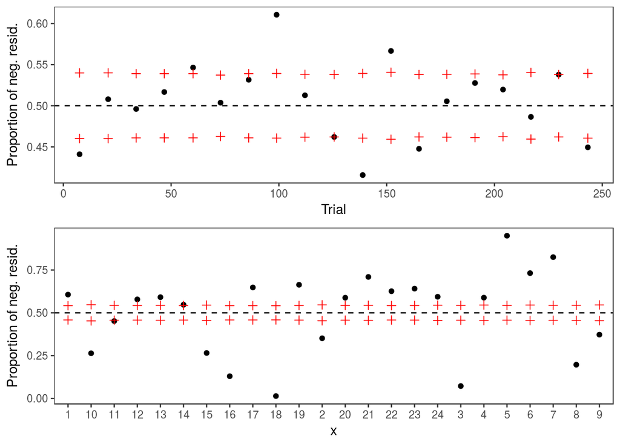

```r
pl <- list()
pl[[1]] <- check1D(m1, x = "Trial") + l_gridQCheck1D(qu = 0.5)
pl[[2]] <- check1D(m1, x = est$Subject) + l_gridQCheck1D(qu = 0.5)

# To plot using grid.arrange, we need to extract the ggplot objects
library(gridExtra)
grid.arrange(grobs = lapply(pl, "[[", "ggObj"))
```

There is a clear non-linear pattern along `Trial`, and there are massive individual differences (depending on `subject`).

3. Add smooth for `Trial` and a random effect for `Subject`:

```r
m1 = qgamV(RT ~ InfFamSize + Age + LogFrequency + WordLength + s(Trial) + s(Subject, bs="re"),
           data=est, qu=0.5)
```

```
## Estimating learning rate. Each dot corresponds to a loss evaluation.
## qu = 0.5..........done
```

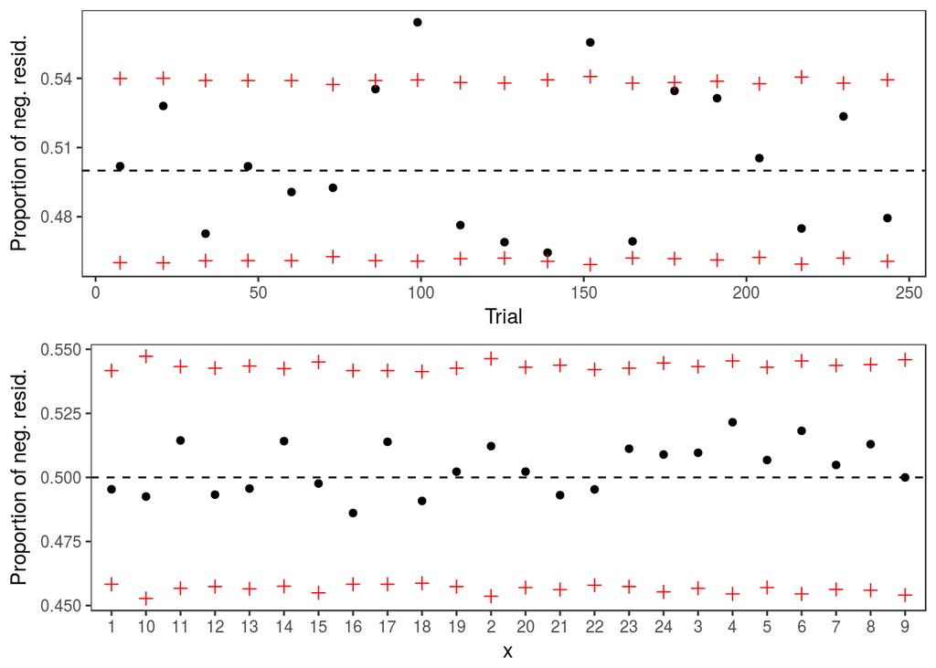

```r
pl <- list()
pl[[1]] <- check1D(m1, x = "Trial") + l_gridQCheck1D(qu = 0.5)
pl[[2]] <- check1D(m1, x = est$Subject) + l_gridQCheck1D(qu = 0.5)

grid.arrange(grobs = lapply(pl, "[[", "ggObj"))
```

```r
summary(m1)
```

```
##
## Family: elf
## Link function: identity
##
## Formula:
## RT ~ InfFamSize + Age + LogFrequency + WordLength + s(Trial) +
##     s(Subject, bs = "re")
##
## Parametric coefficients:
##              Estimate Std. Error z value Pr(>|z|)
## (Intercept)   519.787     78.523   6.620 3.60e-11 ***
## InfFamSize    -13.626      3.471  -3.926 8.65e-05 ***
## Age             3.991      1.646   2.425   0.0153 *
## LogFrequency  -16.088      1.221 -13.171  < 2e-16 ***
## WordLength     30.514      1.266  24.095  < 2e-16 ***
## ---
## Signif. codes:  0 '***' 0.001 '**' 0.01 '*' 0.05 '.' 0.1 ' ' 1
##
## Approximate significance of smooth terms:
##               edf Ref.df  Chi.sq p-value
## s(Trial)    5.028  6.137   21.94 0.00137 **
## s(Subject) 21.746 23.000 1736.16 < 2e-16 ***
## ---
## Signif. codes:  0 '***' 0.001 '**' 0.01 '*' 0.05 '.' 0.1 ' ' 1
##
## R-sq.(adj) =  0.393   Deviance explained = 33.2%
## -REML =  35280  Scale est. = 1         n = 5131
```

There are still some departures from 0.5 along `Trial`, but there is some improvement and the non-linear effect of `Trial` seems important. The diagnostic plot along `Subject` now look very good. Notice that both effects are significant.

4. Try tensor effect

```r
m1 <- qgamV(RT ~ InfFamSize + Age + te(LogFrequency, WordLength) + s(Trial) + s(Subject, bs="re"),
            data=est, qu=0.5)
```

```
## Estimating learning rate. Each dot corresponds to a loss evaluation.
## qu = 0.5............done
```

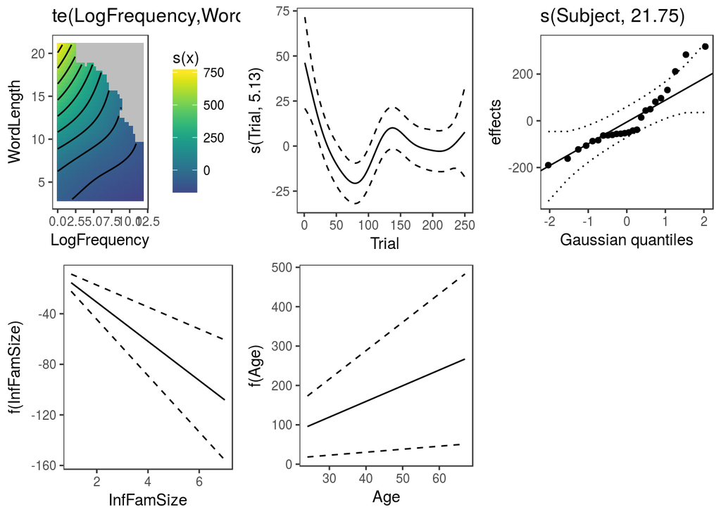

```r
print(plot(m1, allTerms = TRUE), pages = 1)
```

```r
plotRGL(sm(m1, 1), residuals = T) # will not appear in html
rgl.close()
```

The bivariate effect of `LogFrequency` and `WordLength` looks pretty linear to me! We are probably better off using two linear effects.

5. Fit several quantile models

```r
qus <- seq(0.1, 0.9, length.out = 5)
m1 = mqgamV(RT ~ InfFamSize + Age + LogFrequency + WordLength + s(Subject, bs="re") + s(Trial),
            data=est, qu=qus)
```

```
## Estimating learning rate. Each dot corresponds to a loss evaluation.
## qu = 0.5..........done
## qu = 0.3...............done
## qu = 0.7................done
## qu = 0.1................done
## qu = 0.9.........done
```

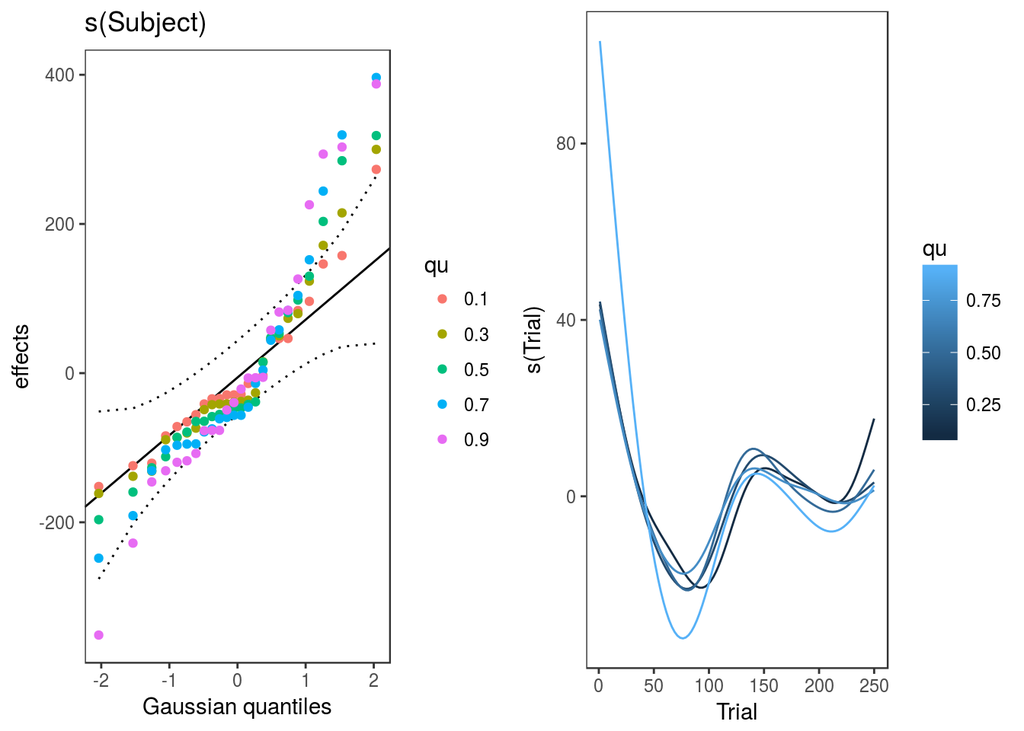

```r
# Plotting all smooth effects
print(plot(m1), pages = 1)
```

The effect of `Trial` shows a fast learning effect, up to around 75 trials, followed by fatigue. It is interesting to notice that the learning effect seems much faster for very slow responses (high RT, quantile 0.9).

We now plot also the parametric effects:

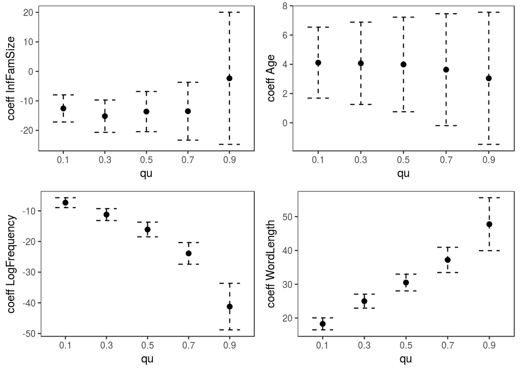

```r
print(plot(m1, allTerms = TRUE, select = 3:6), pages = 1)
```

Notice that all the confidence intervals get wider as we move toward the highest quantile (0.9). This is normal, as the response times distribution is very skewed to the right, hence the data is quite sparse around high quantile. The effects of word frequency and length get stronger as we look at slower responses.